# R Ladies Data Visualization

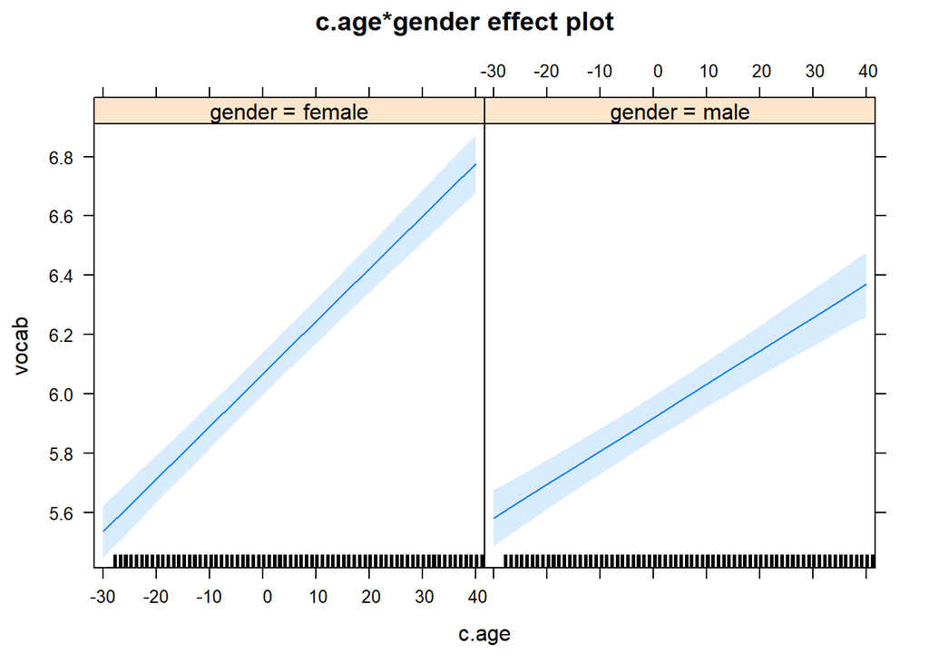

Indeed, we can see that the relationship between age and vocabulary scores is weaker (=smaller slope) for males.

```
## NOTE: c.age:nativeBorn is not a high-order term in the model
```

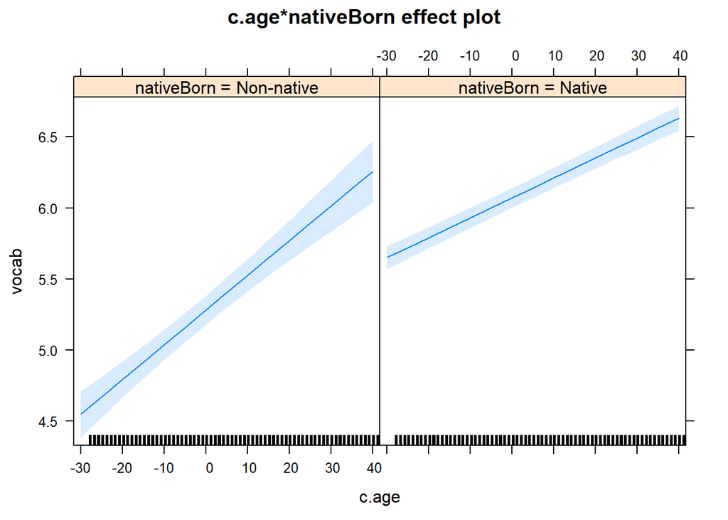

It might be useful to plot these slopes from the model on top on the raw data. This is very easy to do in ggplot: we can combine data from different files together.

```
## NOTE: c.age:nativeBorn is not a high-order term in the model
```

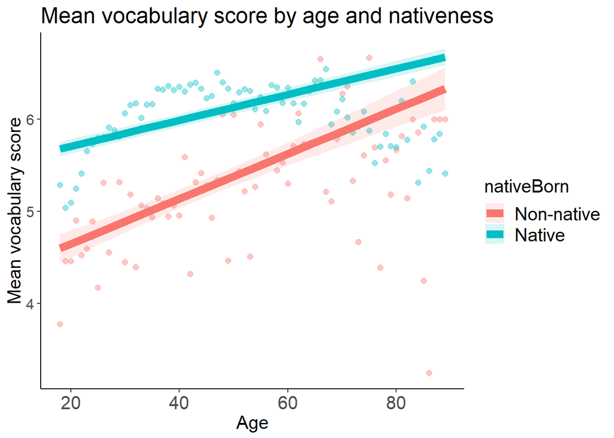

Great! We see that except for the fact that natives have higher scores, nativeness is changing the relationship between age and vocabulary scores (i.e., the slope is steeper for non-natives).

### Plotting (and understanding) triple interactions

```
## NOTE: c.age:nativeBorn:gender is not a high-order term in the model
```

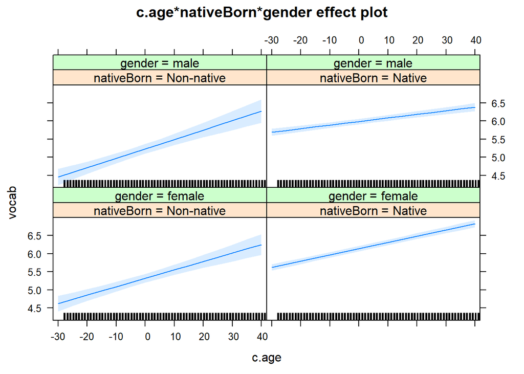

This plot is actually not so clear and it’s hard to see the differences, but the idea is that the significant relationship between age and gender (i.e., males showing a weaker relationship) is somewhat modluated by nativeness (so it is true only for the natives).

Maybe we can try to plot the model AND the raw data together to get a better picture.

```
## NOTE: c.age:nativeBorn:gender is not a high-order term in the model
```

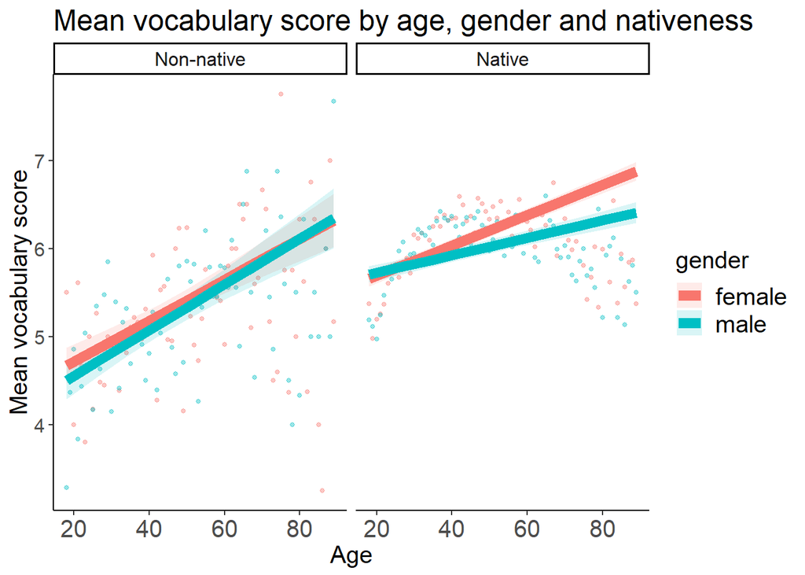

### Time to do some model plotting yourself! :)

1. Creat a new r code chunk, and give it a useful name
2. Plot the interaction between nativeness and gender
3. Plot the interaction between nativeness and education
4. Plot the interaction between gender and education
5. Plot the triple interaction between gender, education and nativeness
6. Plot the raw data + model estimates for one of the interactions above
7. Check: do the plots fit the model’s output and the significance of the interactions?